# STAT5003

Week 7 : Bootstrapping, missing data, and class imbalance

Jaslene Lin

The University of Sydney

# Readings and R functions covered

**Important**

- **Introduction to Statistical Learning**
  - Bootstrap covered in Chapter 5
- **R** functions
  - `naniar:: any_na`
  - `naniar:: are_na`
  - `visdat:: vis_dat`
  - `vidat:: vis_miss`
  - `mice::md.pattern`
  - `mice::marginplot`
  - `ROSE::ovun.sample`
  - `themis::step_smote`

This presentation is based on the [SOLES reveal.js Quarto template](https://github.com/usyd-soles-edu/soles-revealjs) and is licensed under a [Creative Commons Attribution 4.0 International License](http://creativecommons.org/licenses/by/4.0/).

# Bootstrap

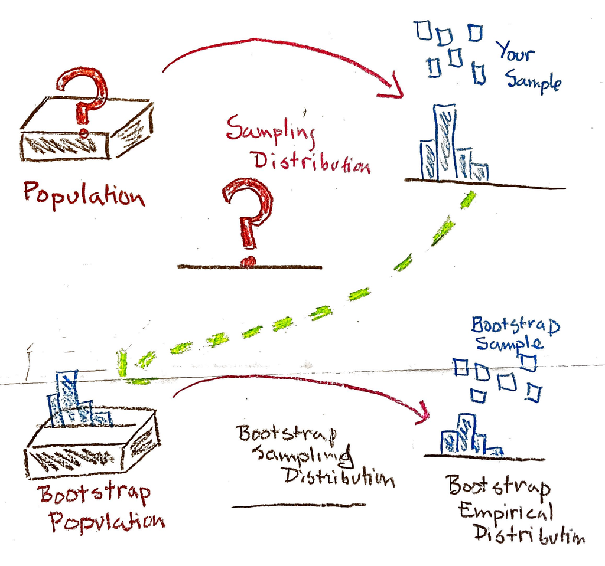

Source

## Bootstrap

- The bootstrap is a flexible and powerful statistical tool that can be used to quantify the uncertainty associated with a given estimator or statistical learning method.
- For example, it can provide an estimate of the standard error of a coefficient, or a confidence interval for that coefficient.

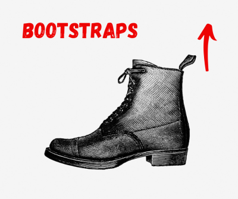

## Simple example

- Suppose that we wish to invest a fixed sum of money in two financial assets that yield returns of $X$ and $Y$ where $X$ and $Y$ are random quantities
- The goal is to create a portfolio by investing fraction $\alpha$ of our wealth in $X$ and $(1 − \alpha)$ in $Y$
- Want to choose to minimise the total risk of the investment. Mathematically, this involves minimising the variance of our investment portfolio $\text{Var}(\alpha X + (1 − \alpha) Y)$
- The solution to this problem (*via calculus*) is
  $$\begin{align}
  \alpha = \frac{\sigma^2_Y - \sigma_{XY}}{\sigma_X^2 + \sigma_Y^2 - 2\sigma_{XY}} \nonumber
  \end{align}$$
  - $\sigma_X^2 = \text{Var}(X)$, $\sigma_Y^2 = \text{Var}(Y)$, and $\sigma_{XY} = \text{Cov}(X, Y)$

## A Thought Experiment

- The values of $\sigma_X^2$, $\sigma_Y^2$, and $\sigma_{XY}$ are unknown but estimates can be computed from the data
- The estimate of $\alpha$ that minimises the variance of the investment can then be computed with
  $$\begin{align}
  \widehat{\alpha} = \frac{\widehat{\sigma}^2_Y - \widehat{\sigma}_{XY}}{\widehat{\sigma}_X^2 + \widehat{\sigma}_Y^2 - 2\widehat{\sigma}_{XY}} \nonumber
  \end{align}$$
- Suppose that $X$ and $Y$ can be sampled from the population repeatedly
- You sample **100 pairs of (**$X$, $Y$) from the population — this gives you one dataset.
- You calculate an estimate, say $\widehat{\alpha}$, from this sample.
- Now, repeat this **sampling process 1000 times**, each time drawing a new random sample of 100 pairs from the population and computing $\widehat{\alpha}$.
- You will end up with $\widehat{\alpha}_1, \widehat{\alpha}_2, \ldots, \widehat{\alpha}_{1000}$

## Simulations in R

- Consider a population with $\sigma_X^2 = 1$, $\sigma_Y^2 = 1.5$, and $\sigma_{XY} = 0.5 \Rightarrow \alpha = 2/3$.

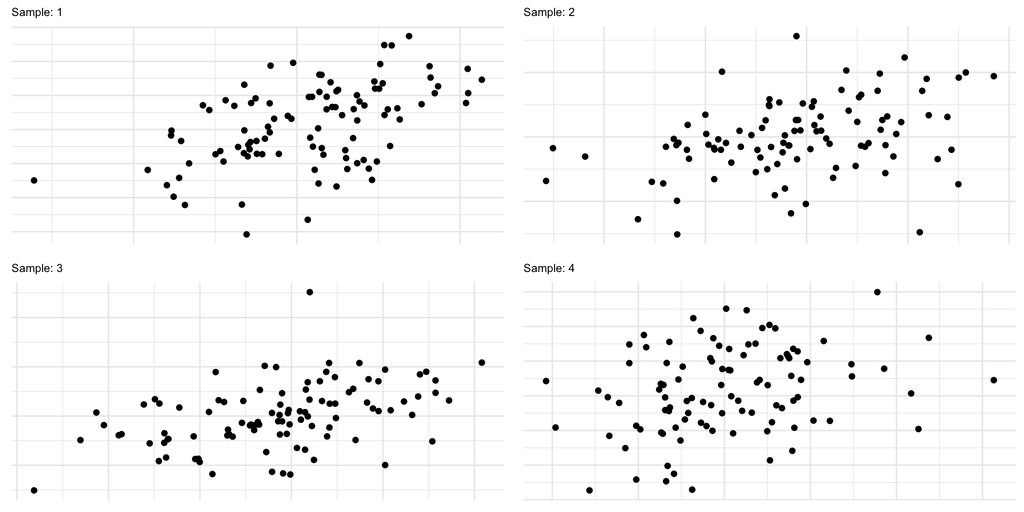

From left to right, top to bottom, the estimates for $\alpha$ are 0.659, 0.683, 0.726, 0.68.

## Sampling Variability and the Variance of an Estimator

**Note**

**Key Idea**: When we estimate a parameter, the result depends on the sample. If we collecte a different sample, the estimate would likely be different.

- This phenomenon is called **sampling variability**.
- The **variance of an estimator** captures this variability:
  - If an estimator has **low variance**, repeated samples yield similar results.
  - If it has **high variance**, the estimate fluctuates a lot between samples.
- Ideally, we want estimators that are:
  - **Unbiased** (on average, close to the true value)
  - **Low variance** (stable across samples)
- Estimating the variance of an estimator requires repeatedly sample from the population.

## Esmating the Variability of $\widehat{\alpha}$

- Consider the mean of all the parameter estimates
  $$\begin{align*}
  \overline{\widehat{\alpha}} = \frac{1}{1000} \sum_{k = 1}^{1000} \widehat{\alpha}_k = 0.6662595
  \end{align*}$$
  - This is close to the true value of 0.6666667
- Estimate of the standard error using the standard deviation of all the estimates
  $$\begin{align*}
  \sqrt{\frac{1}{1000 - 1} \sum_{k = 1}^{1000} \left( \widehat{\alpha}_k - \overline{\widehat{\alpha}}\right)^2} = 0.0760217
  \end{align*}$$
- This gives an intuitive description of the reliability of the estimator
  - For a random sample the estimate would vary around the true value by 0.0760217

## Application in Reality

- We can’t actually sample repeatedly from the population
  - In reality, we **only have one dataset**, not the entire population to draw from.

### Bootstrap attempts to mimic this process

- Instead of sampling new independent observations from the population
  - Re-sample observations from the data *with replacement*
  - Some observations may appear more than once while others not at all

## Bootstrap resampling algorithm

- Essentially sampling with replacement from the original sample

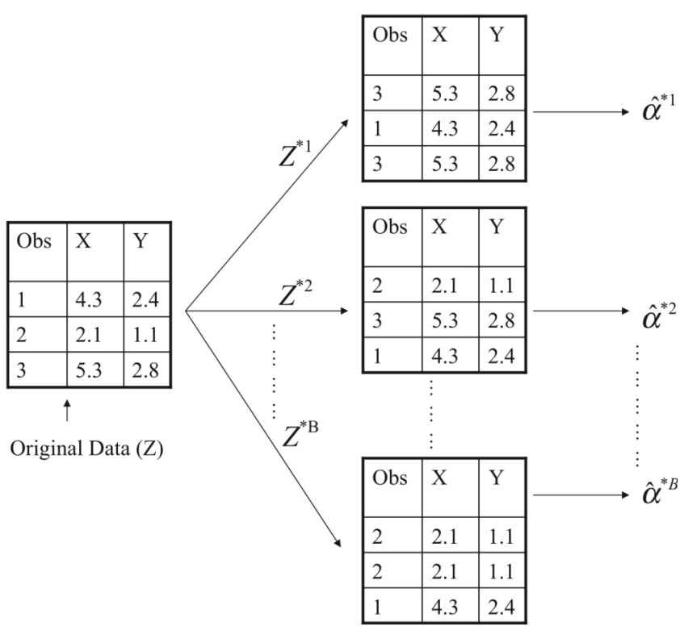

## Results bootstrap vs population

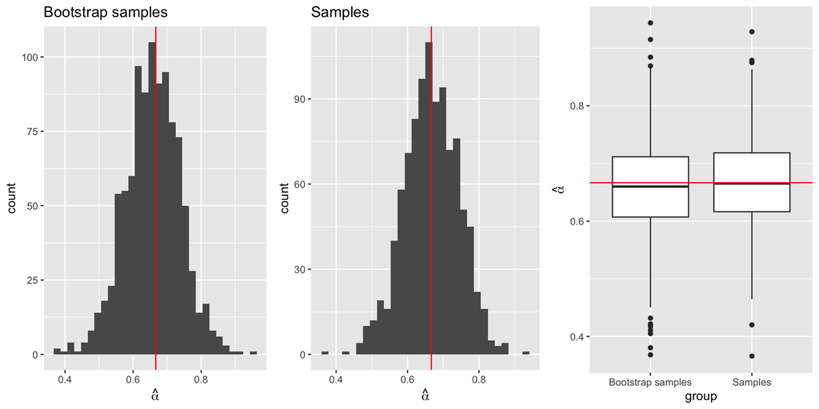

# Missing data

```
The best thing to do with missing data is to not have any.

    --- Gertrude Mary Cox (statistician)
```

- Working with real-world data = working with missing data

## Any Missing Data?

```r
library(naniar)

glimpse(airquality)
```

```
Rows: 153
Columns: 6
$ Ozone   <int> 41, 36, 12, 18, NA, 28, 23, 19, 8, NA, 7, 16, 11, 14, 18, 14, …
$ Solar.R <int> 190, 118, 149, 313, NA, NA, 299, 99, 19, 194, NA, 256, 290, 27…
$ Wind    <dbl> 7.4, 8.0, 12.6, 11.5, 14.3, 14.9, 8.6, 13.8, 20.1, 8.6, 6.9, 9…
$ Temp    <int> 67, 72, 74, 62, 56, 66, 65, 59, 61, 69, 74, 69, 66, 68, 58, 64…
$ Month   <int> 5, 5, 5, 5, 5, 5, 5, 5, 5, 5, 5, 5, 5, 5, 5, 5, 5, 5, 5, 5, 5,…
$ Day     <int> 1, 2, 3, 4, 5, 6, 7, 8, 9, 10, 11, 12, 13, 14, 15, 16, 17, 18,…
```

```r
# str(airquality)

any_na(airquality)
```

```
[1] TRUE
```

```r
head(are_na(airquality$Solar.R))
```

```
[1] FALSE FALSE FALSE FALSE  TRUE  TRUE
```

```r
any_na(iris)
```

```
[1] FALSE
```

## Visualising Missingness

```r
library(visdat)
library(patchwork)

p1 <- vis_dat(airquality)

p2 <- vis_miss(airquality)

p1 + p2
```

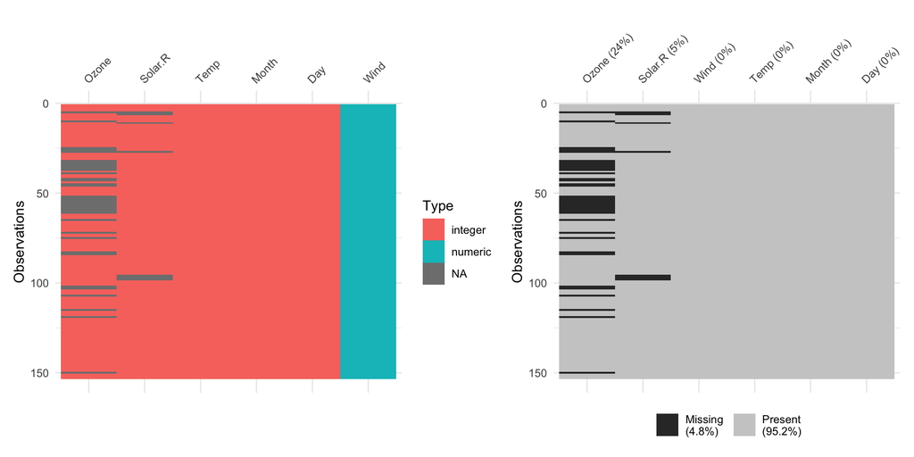

## Missing Mechanisms

**1. Missing Completely at Random (MCAR)**

- Missingness has no association with any data you have **observed**, or **not observed**. Missingness occurs **purely by chance**.
- **Example:**

| Test | Special Consideration |
| --- | --- |
| 65 | FALSE |
| NA | TRUE |
| 80 | FALSE |
| 70 | FALSE |
| NA | FALSE |

- **Handling**
  - Imputation is advisable
  - Deleting observations will not bias the results, but may reduce the model power due to the reduced sample size thus limiting inference.

## Missing Mechanisms

**2. Missing at Random (MAR)**

- Missingness depends on **data observed**, but **not data unobserved**.
- **Example**:

| Test | Special Consideration | Health |
| --- | --- | --- |
| 65 | FALSE | Good |
| NA | TRUE | Poor |
| 80 | FALSE | Good |
| 70 | FALSE | Good |
| NA | FALSE | Poor |

- **Handling:**
  - Use **imputation** to adjust for missing data.

## Mechanism for missing data

**3. Missing Not at Random (MNAR)**

- Missingness is related to unobserved data
- **Example**:

| Test | Special Consideration | Health |
| --- | --- | --- |
| 65 | FALSE | Good |
| NA | TRUE | NA |
| 80 | FALSE | Good |
| 70 | FALSE | Good |
| NA | FALSE | NA |

- **Handling**
  - Requires **modeling the missingness mechanism** to correct biases.

## Identifying different types of missingness

- It’s often **difficult to determine the missingness mechanism** using statistical tests alone.
- Instead, rely on:
  - **Domain knowledge** and understanding of the **data collection process**
  - **Predictive models**: Fit a classification model to predict missingness—if successful, data may be MAR.
- For testing **MCAR**:
  - Use tests like `mcar_test()` from the `naniar` package.
  - Based on Little’s MCAR test (Little, 1988), which assumes multivariate normality.

## Dealing with missing values

- For categorical data, “missing” can be a category
  - For example, in a survey poll, if someone does not want to disclose who they want to vote for, it then can be in the category “undecided”
- Delete data with missing value. Two options:
  - Omit the variable with missing data
  - Omit the observation with missing data
  - Drawbacks are that you might be throwing away valuable information, or inadvertently introduce bias into the data
- **Impute: fill in the missingness**

## Single imputation

- Single imputation replaces the missing value with a single value
- Examples:
  - Replace the missing values of a feature with the mean/median value of that feature
  - Use a predictive method for filling in the missing values, e.g., regression trees, kNN
  - Replace the missing value with the last observed value for that feature
- **Drawbacks**:

  With single imputation, once the missing data are added back, it is treated as valid observed data, hence the uncertainty in the missing value data is lost

## Multiple imputation

- Multiple imputation accounts for uncertainty in the imputation process
- Generally follows three steps:
  - Impute the data $k$ times (this can be done using a single imputation method)
  - Perform analysis (e.g., regression/classification) on each of the $k$ imputed data sets
  - Pool the $k$ results together
- Multiple Imputation by Chained Equation (MICE) is a popular method
  - See [mice: Multivariate Imputation by Chained Equations in R](https://www.jstatsoft.org/article/view/v045i03)

## Basic impute, deterministic imputation, random imputatation

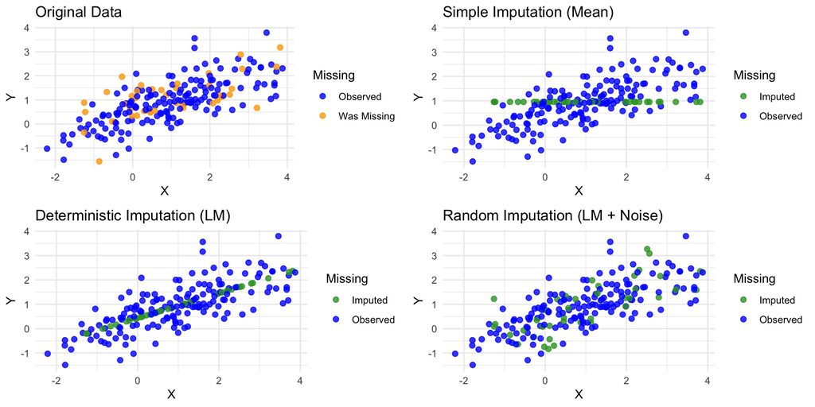

```r
# 1. Simple Imputation (mean)
mn <- mean(dat$Y, na.rm = TRUE)
dat.simple <- dat.missing
dat.simple$Y[is.na(dat.simple$Y)] <- mn
dat.simple$Missing <- ifelse(is.na(dat.missing$Y), "Imputed", "Observed")

# 2. Deterministic Imputation (linear model)
simp.lm <- lm(Y ~ X, data = dat.missing)
simple.preds <- predict(simp.lm, newdata = dat.missing[missing.inds, ])
dat.determ <- dat.missing
dat.determ$Y[missing.inds] <- simple.preds
dat.determ$Missing <- ifelse(is.na(dat.missing$Y), "Imputed", "Observed")

# 3. Random Imputation (add noise to regression)
est.sigma <- sigma(simp.lm)
rand.preds <- simple.preds + rnorm(length(simple.preds), sd = est.sigma)
dat.rand <- dat.missing
dat.rand$Y[missing.inds] <- rand.preds
dat.rand$Missing <- ifelse(is.na(dat.missing$Y), "Imputed", "Observed")

# Add plot titles
attr(dat, "name") <- "Original Data"

attr(dat.simple, "name") <- "Simple Imputation (Mean)"
attr(dat.determ, "name") <- "Deterministic Imputation (LM)"
attr(dat.rand, "name") <- "Random Imputation (LM + Noise)"

# Combine and plot
all_datasets <- list(dat, dat.simple, dat.determ, dat.rand)

# Plot
plots <- lapply(all_datasets, function(d) {
  ggplot(d, aes(x = X, y = Y, color = Missing)) +
    geom_point(alpha = 0.8, size = 2) +
    theme_minimal() +
    scale_color_manual(values = c(
      "Observed" = "blue",
      "Missing" = "red",
      "Imputed" = "#33a02c",
      "Was Missing" = "orange"
    )) +
    ggtitle(attr(d, "name"))
})

# Display plots
grid.arrange(grobs = plots, ncol = 2)
```

## Other practical suggestions

- It is highly recommend that you visualize your data to look for patterns of missingness
- Be wary of variables with high proportion of missing data. However, this might not be a problem if imputation is applicable and performs well
- Some algorithms can cope with missingness (e.g., decision trees) and so you may not need to do imputation
- If you believe the pattern of missingness is informative, you can include it as a dummy variable

## R packages for dealing with missing values

- Impute (Bioconductor package)
  - KNN imputation, written for microarray data
- MICE
  - Multiple imputation
- missForest
  - Uses Random Forest (in upcoming tree-based module) to predict the missing values
  - Can be used for continuous and categorical data
- Amelia II
  - Multiple imputation

# Class imbalance

## Class imbalance

- Let’s say we have a classification problem to detect credit card fraud, but only 1% of transactions are fraud.
- If you use accuracy as the metric to optimise, then just classifying every transaction as not-fraud will get you to 99% accuracy!

## Inspect a SVM

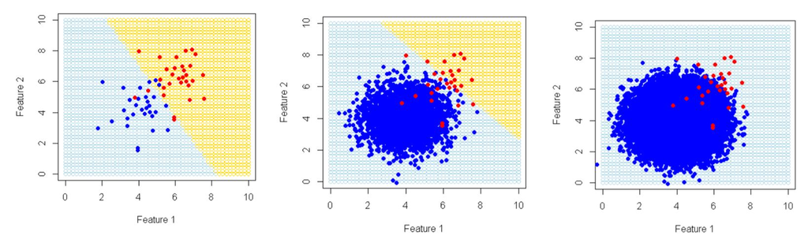

- Notice the negative (blue) class swamps the classifier
- Boundary moves and disappears favouring only the negative class

## Handelling Class Imbalance

### 1. Use different metrics

- $F_1$ score
  $$\begin{align*}
  F_1 = \frac{2\text{TP}}{2\text{TP} + \text{FP} + \text{FN}} = \frac{2\times \text{Precision}\times\text{Recall}}{\text{Precision} + \text{Recall}}
  \end{align*}$$
- Area Under Curve (AUC) for the ROC
- **Cohen’s Kappa**

## What is Cohen’s Kappa metric?

$$\kappa = \frac{P_o - P_e}{1 - P_e}$$
Where:

- $P_o$= Observed accuracy
- $P_e$ = Expected accuracy generated simply by chance

### Interpretation Guide

| Kappa Value | Strength of Agreement |
| --- | --- |
| < 0 | Less than chance |
| 0.01–0.20 | Slight |
| 0.21–0.40 | Fair |
| 0.41–0.60 | Moderate |
| 0.61–0.80 | Substantial |
| 0.81–1.00 | Almost perfect |

## Example: Binary Classification – Spam Detection

|  | Actual: Spam | Actual: Not Spam |
| --- | --- | --- |
| **Predicted: Spam** | 30 | 15 |
| **Predicted: Not Spam** | 10 | 45 |

- Observed accuracy:
  $$P_o = \frac{30 + 45}{100} = 0.75$$
- Class proportions:
  - Predicted Spam: ( 45% ); Predicted Not Spam: ( 55% )
  - Actual Spam: ( 40% ); Actual Not Spam: ( 60% )
- Expected accuracy:
  $$P_e = (0.4 \times 0.45) + (0.6 \times 0.55) = 0.18 + 0.33 = 0.51$$
- Kappa:
  $$\kappa = \frac{0.75 - 0.51}{1 - 0.51} = \frac{0.24}{0.49} \approx 0.49$$

## Cohen’s Kappa for Class Imbalance Classification

- Example
  - $100$ samples with $2\%$ positive class and $98\%$ negative class
  - A classifier classifies all samples as negative class
  - Lead to accuracy $98\%$, but what about other performance measures?
  - Sensitivity: 0; Specificity: 1; Cohen’s kappa: 0

You can compute Kappa in R using `caret::confusionMatrix`

```
Confusion Matrix and Statistics

          Reference
Prediction positive negative
  positive        0        0
  negative        2       98

               Accuracy : 0.98
                 95% CI : (0.9296, 0.9976)
    No Information Rate : 0.98
    P-Value [Acc > NIR] : 0.6767

                  Kappa : 0

 Mcnemar's Test P-Value : 0.4795

            Sensitivity : 0.00
            Specificity : 1.00
         Pos Pred Value :  NaN
         Neg Pred Value : 0.98
             Prevalence : 0.02
         Detection Rate : 0.00
   Detection Prevalence : 0.00
      Balanced Accuracy : 0.50

       'Positive' Class : positive
```

```
Kappa
    0
```

## Handelling Class Imbalance

### 2. Modify the Data

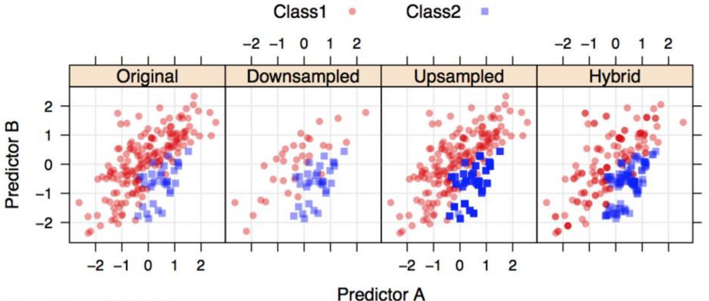

## Down-sampling

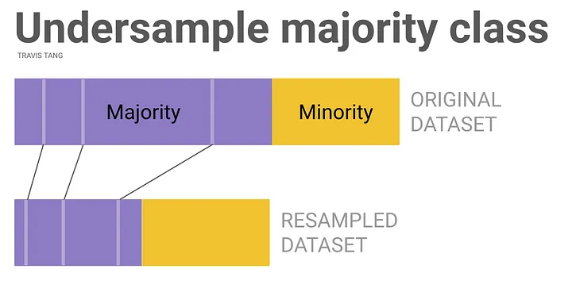

Travis Tang from Medium

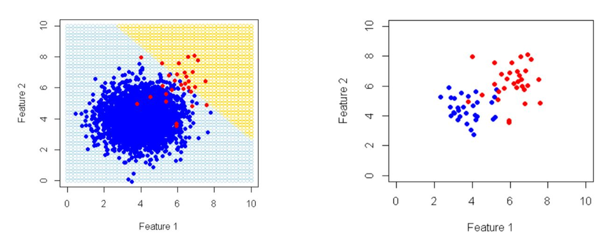

- Advantage: it does not introduce duplicates and/or artificial instances.
- Disadvantages:
  - Not all data points are used.
  - Potentially removing useful information.
- Better choice for data with very high class imbalance.

## Up-sampling

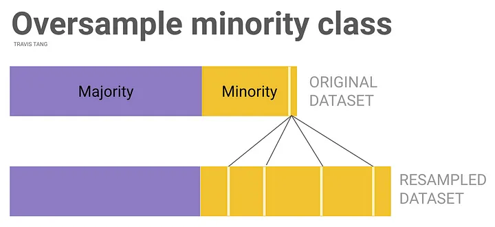

Travis Tang from Medium

- Random up-sampling
- Disadvantages:
  - creates duplicated and/or artificial instances
  - can introduce bias and/or noise to the original data

## Create synthetic samples of the minority class

- Synthetic Minority Over-sampling Technique (SMOTE) is a popular algorithm
- It creates synthetic samples from the minority class by:
  - Finding the $k$-nearest-neighbours for minority class observations
  - Randomly choosing one of the $k$-nearest-neighbours, then using it to create a similar but random new observation
- Be careful that you split your data into training/test sets before doing any oversample/SMOTE. Otherwise, you will leak information from training to test data set.

## Handelling Class Imbalance via `R`

- Balanced Resampling with `ROSE::ovun.sample()` can perform **under/over-sampling** or **hybrid** combines over- and under-sampling for balanced output.
- `themis::step_smote` helps balance binary or multiclass classification problems by generating synthetic examples (via $knn$) of the minority class.

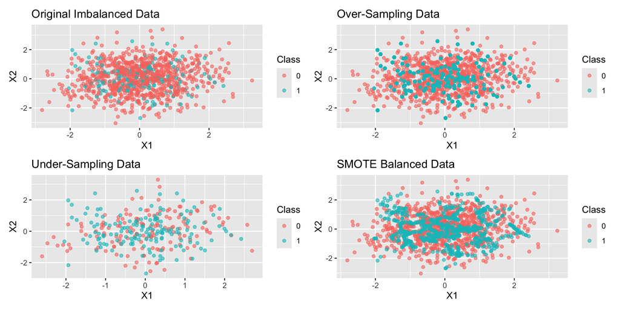